# A2: ANÁLISIS DESCRIPTIVO E INFERENCIAL

M2.854 - Estadística Avanzada

Juan Pablo Botero Suaza

19 de abril, 2019

# 1 Introducción

Los datos que se analizan en esta actividad corresponden al análisis de satisfacción laboral trabajado en la actividad 1. El objetivo es investigar si la satisfacción laboral de los trabajadores está relacionada con la calificación del trabajo y el nivel de estudios, entre otras variables.

El archivo se denomina rawDataClean.csv, y contiene 1920 registros y 12 variables. Estas variables son: city, sex, educ_level, job_type, happiness, age, seniority, sick_leave, sick_leave_b, work_hours, Cho_initial,Cho_final.

Los datos recogidos para cada trabajador son:

1. La ciudad del puesto de trabajo
2. El sexo del trabajador
3. El nivel de estudio del trabajador (1: sin estudios, 2: estudios primarios, 3: educación secundaria o educación profesional, 4: universitarios)
4. El tipo de trabajo (C: calificado, PC: poco cualificado)
5. La satisfacción laboral del trabajador (comprendida entre 0 y 10)
6. La edad (años)
7. La antigüedad (en años)
8. Los días de baja en el último año laboral
9. Si el trabajador estuvo de baja o no en el último año (variable binaria)
10. Las horas que trabaja a la semana en promedio
11. El nivel de colesterol en la penúltima revisión médica (mmol/L)
12. El nivel de colesterol en la última revisión médica (mmol/L).

# 2 Análisis descriptivo

## 2.1 Carga de los datos

Cargar el archivo de datos rawDataClean.csv. Una vez cargado el archivo, valida que los tipos de datos son los correctos. Si no es así, conviertelos al tipo oportuno.

```r
data_clean<-read.csv("rawDataClean.csv", header=TRUE,sep=",",dec=".")
str(data_clean)
```

```
## 'data.frame':    1920 obs. of  12 variables:
##  $ city        : Factor w/ 3 levels "Barcelona","Madrid",..: 1 1 1 1 1 1 1 1 1 1 ...
##  $ sex         : Factor w/ 2 levels "F","M": 2 2 2 2 2 2 2 2 2 2 ...
##  $ educ_level  : int  1 1 1 1 1 1 1 1 1 1 ...
##  $ job_type    : int  1 1 1 1 1 1 1 1 1 1 ...
##  $ happiness   : num  7.23 5.93 5.83 6.33 8.93 7.23 7.83 9.23 7.63 5.73 ...
##  $ age         : int  45 36 34 37 35 29 26 44 23 46 ...
##  $ seniority   : int  23 19 18 18 19 14 13 23 2 22 ...
##  $ sick_leave  : int  0 0 0 0 0 6 0 0 24 36 ...
##  $ sick_leave_b: int  0 0 0 0 0 1 0 0 1 1 ...
##  $ work_hours  : num  35.4 41.3 36.6 40.5 36 32.2 36.6 35.5 36.3 34.1 ...
##  $ Cho_initial : num  1.15 1.05 1.15 1.15 1.15 1.05 1.15 1.15 1.15 1.15 ...
##  $ Cho_final   : num  1.33 1.1 1.25 1.21 1.31 1.18 1.2 1.28 1.33 1.21 ...
```

El set de datos contiene 12 variables con un total de 1920 observaciones

| city | sex | educ_level | job_type | happiness | age | seniority | sick_leave | sick_leave_b | work_hours | Cho_initial | Cho_final |
| --- | --- | --- | --- | --- | --- | --- | --- | --- | --- | --- | --- |
| Barcelona | M | 1 | 1 | 7.23 | 45 | 23 | 0 | 0 | 35.4 | 1.15 | 1.33 |
| Barcelona | M | 1 | 1 | 5.93 | 36 | 19 | 0 | 0 | 41.3 | 1.05 | 1.10 |
| Barcelona | M | 1 | 1 | 5.83 | 34 | 18 | 0 | 0 | 36.6 | 1.15 | 1.25 |
| Barcelona | M | 1 | 1 | 6.33 | 37 | 18 | 0 | 0 | 40.5 | 1.15 | 1.21 |
| Barcelona | M | 1 | 1 | 8.93 | 35 | 19 | 0 | 0 | 36.0 | 1.15 | 1.31 |
| Barcelona | M | 1 | 1 | 7.23 | 29 | 14 | 6 | 1 | 32.2 | 1.05 | 1.18 |

**Verificar existencia de valores NA o vacios para cada una de las variables**

```r
colSums(is.na(data_clean))
```

```
##         city          sex   educ_level     job_type    happiness
##            0            0            0            0            0
##          age    seniority   sick_leave sick_leave_b   work_hours
##            0            0            0            0            0
##  Cho_initial    Cho_final
##            0            0
```

```r
colSums(data_clean=="")
```

```
##         city          sex   educ_level     job_type    happiness
##            0            0            0            0            0
##          age    seniority   sick_leave sick_leave_b   work_hours
##            0            0            0            0            0
##  Cho_initial    Cho_final
##            0            0
```

Los resultados indican que el set datos presenta datos completos y sin valores NA para cada una de las variables.

**Estandarización de variables de acuerdo a la definción**

*Variable educ_level*: El nivel de estudios se estandariza con la siguiente abreviatura donde aparece el valor 1 cambiar por el valor N, donde aparece el valor 2 cambiar por el valor P, donde aparece el valor 3 cambiar por el valor S, donde aparece el valor 4 cambiar por el valor U. Siendo N: sin estudios, P: estudios primarios, S:educación secundaria o educación profesional, U: universitarios.

```r
data_clean[c("educ_level")]<-factor(data_clean[,c("educ_level")],levels=c(1,2,3,4), labels=c("N","P","S","U"),ordered = TRUE)
head(data_clean$educ_level)
```

```
## [1] N N N N N N
## Levels: N < P < S < U
```

*Variable job_type*: El tipo de trabajo se estandariza con la siguiente abreviatura donde aparece el valor 1 cambiar por el valor C, donde aparece el valor 2 cambiar por el valor PC. Siendo C trabajo cualificado y PC poco cualificado.

```r
data_clean[c("job_type")]<-factor(data_clean[,c("job_type")],levels=c(1,2), labels=c("C","PC"))
head(data_clean$job_type)
```

```
## [1] C C C C C C
## Levels: C PC
```

*Variable sick_leave_b*: Variable categórica oculta como variable cuantitativa, si tuvo (1) o no baja (0) en el último año laboral. Se aplica criterio de modificación, el valor “0”" por NB y el valor “1”" por SB. Siendo NB: no tuvo baja y SB: si tuvo baja.

```r
data_clean["sick_leave_b"]<-factor(data_clean[,c("sick_leave_b")],levels=c(0,1), labels=c("NB","SB"))
head(data_clean$sick_leave_b)
```

```
## [1] NB NB NB NB NB SB
## Levels: NB SB
```

Conjunto de datos luego del proceso de estandarización

| city | sex | educ_level | job_type | happiness | age | seniority | sick_leave | sick_leave_b | work_hours | Cho_initial | Cho_final |
| --- | --- | --- | --- | --- | --- | --- | --- | --- | --- | --- | --- |
| Barcelona | M | N | C | 7.23 | 45 | 23 | 0 | NB | 35.4 | 1.15 | 1.33 |
| Barcelona | M | N | C | 5.93 | 36 | 19 | 0 | NB | 41.3 | 1.05 | 1.10 |
| Barcelona | M | N | C | 5.83 | 34 | 18 | 0 | NB | 36.6 | 1.15 | 1.25 |
| Barcelona | M | N | C | 6.33 | 37 | 18 | 0 | NB | 40.5 | 1.15 | 1.21 |
| Barcelona | M | N | C | 8.93 | 35 | 19 | 0 | NB | 36.0 | 1.15 | 1.31 |
| Barcelona | M | N | C | 7.23 | 29 | 14 | 6 | SB | 32.2 | 1.05 | 1.18 |

## 2.2 Análisis descriptivo visual

Representa gráficamente las variables del conjunto de datos para poder visualizar la distribución de valores de las variables. Elije el gráfico más apropiado para cada variable.

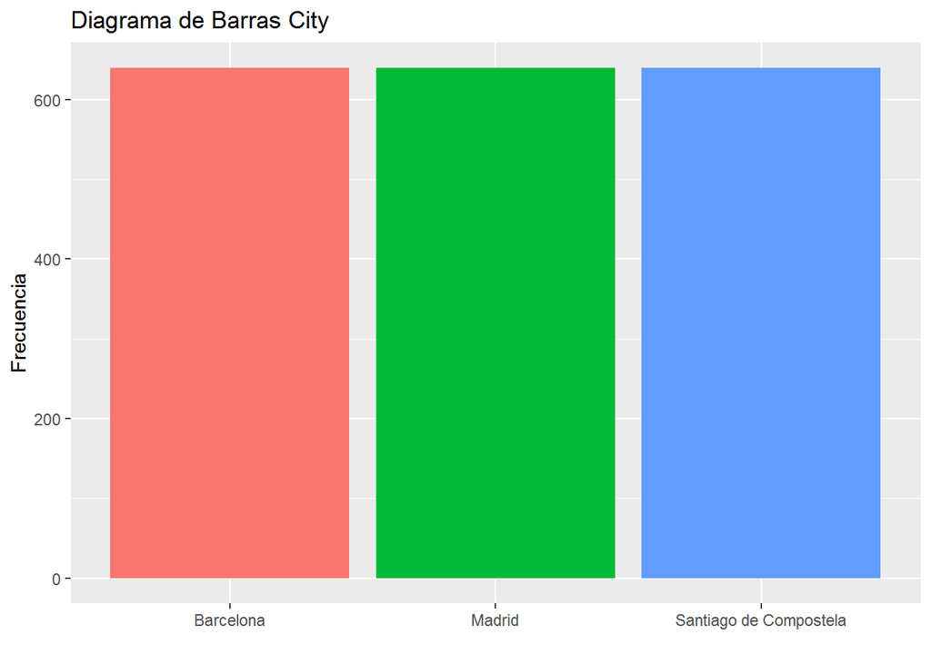

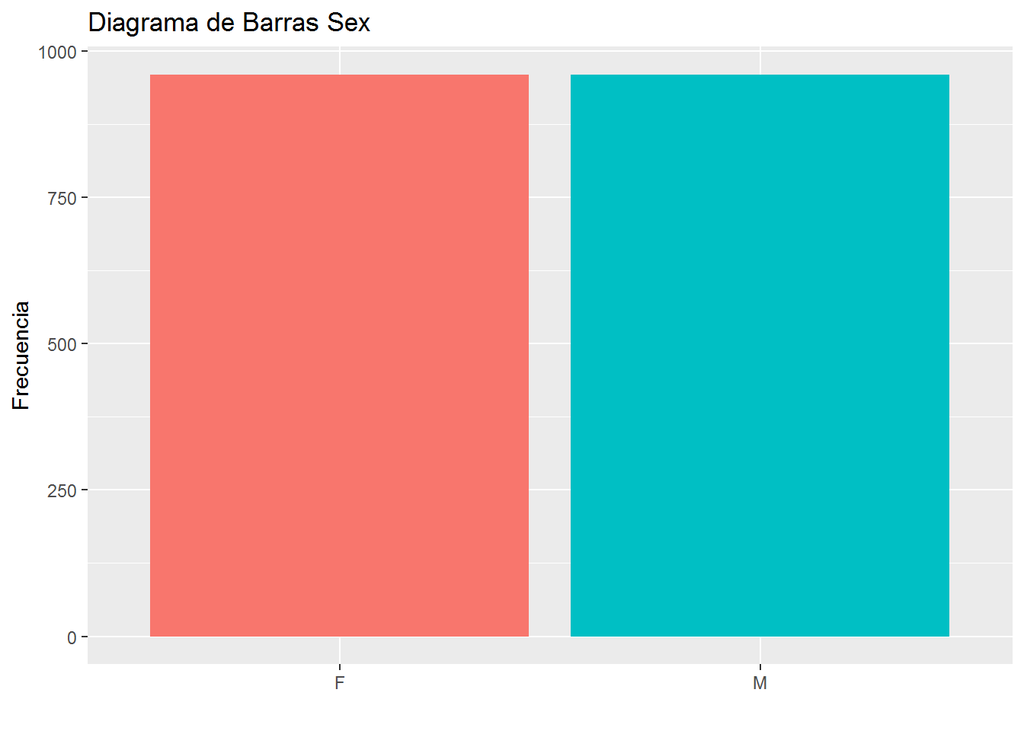

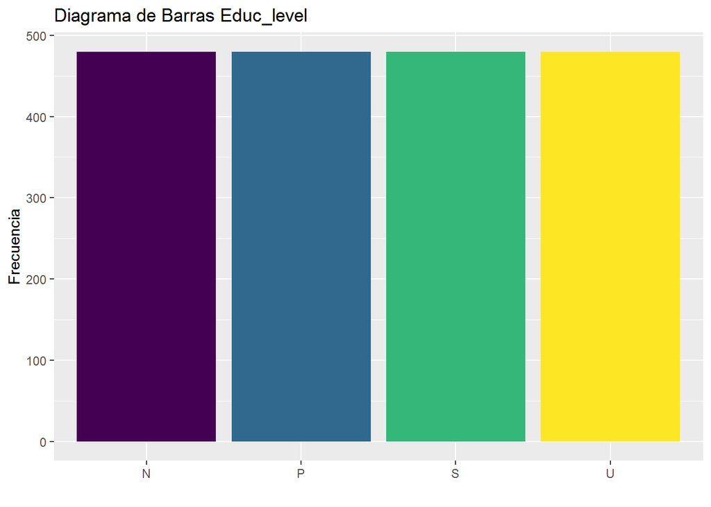

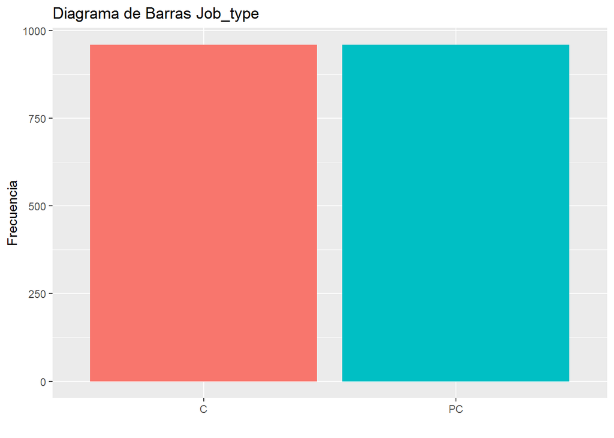

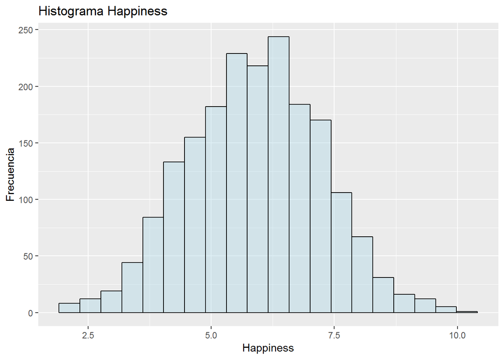

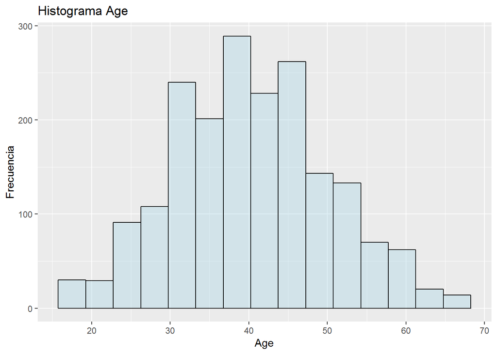

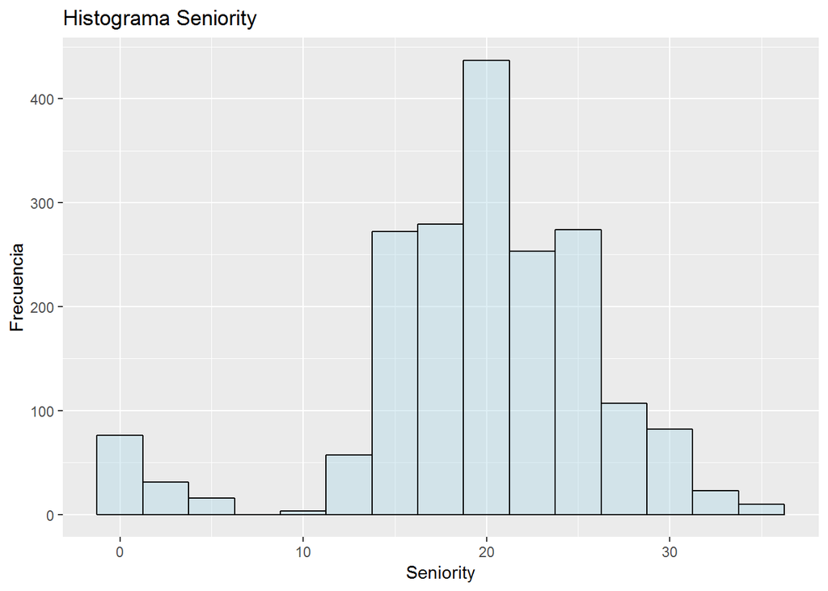

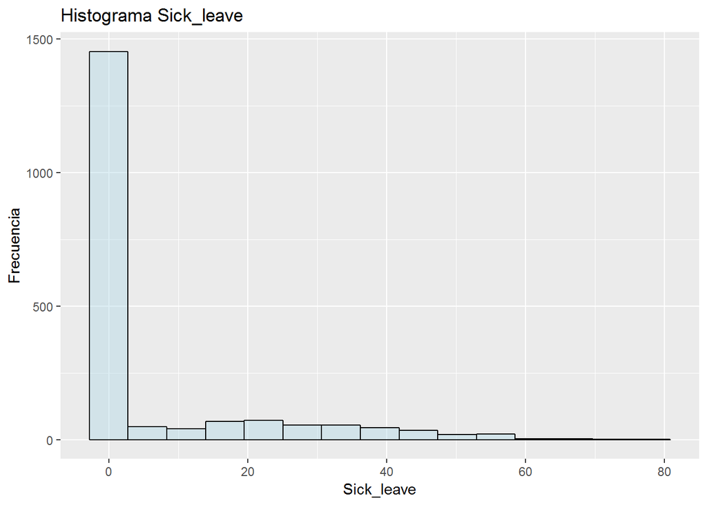

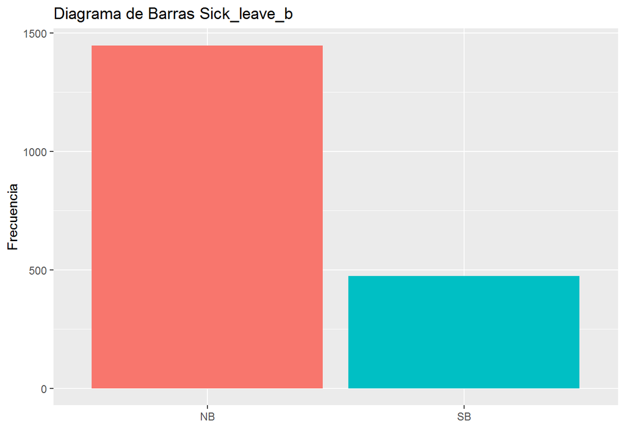

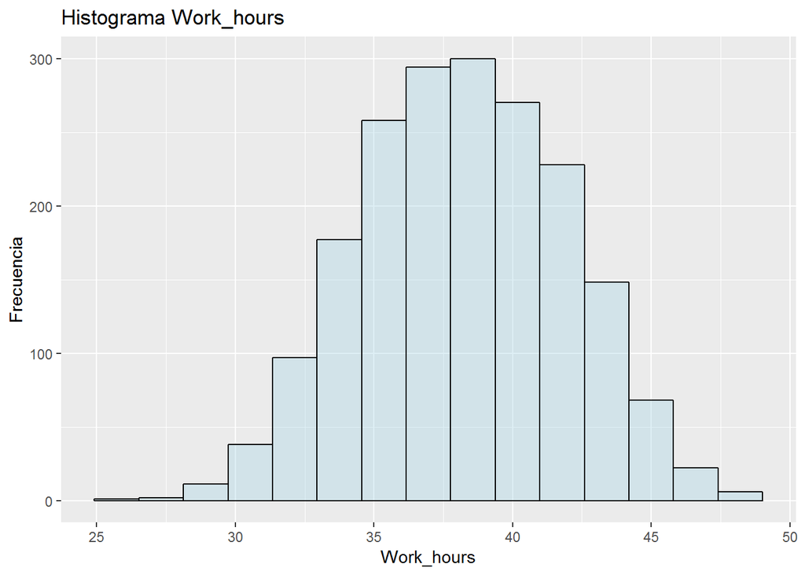

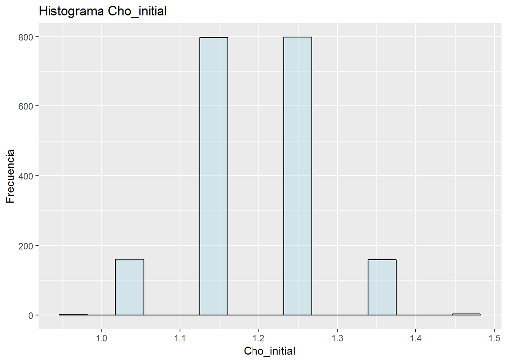

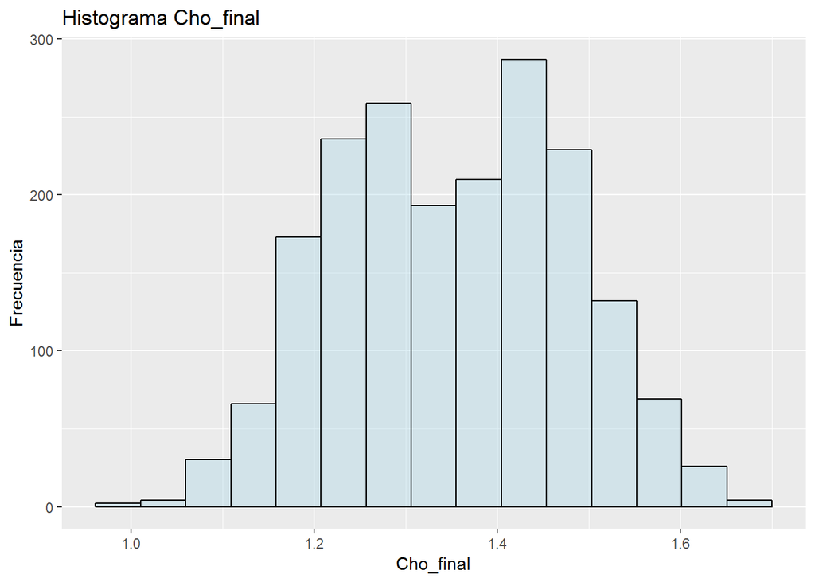

# 3 Estadística inferencial

## 3.1 Intervalo de confianza

Representa, si no lo has hecho en la sección anterior, la distribución de valores de la variable happiness en un histograma. Interpreta el gráfico.

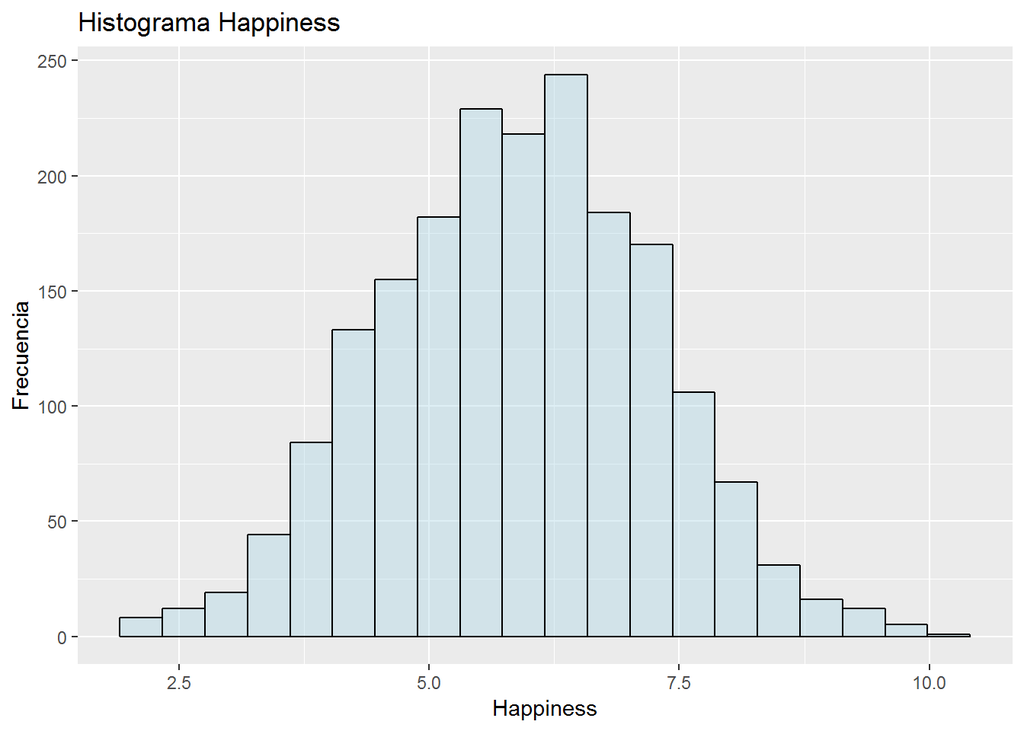

Se puede infererir que la distribución de los datos presenta cierto nivel de simetria unimodal para un valor cercano a 6, también podemos afirmar que gran parte de la muestra poblacional tiene un nivel de satisfacción entre 5 y 7.5.

A continuación, calcula el intervalo de confianza del 90% de la variable happiness. También, explica cuál es la interpretación del intervalo de confianza obtenido.

**Test de normalidad Shapiro-Wilk:**

[https://en.wikipedia.org/wiki/Shapiro-Wilk_test]

“Se usa para contrastar la normalidad de un conjunto de datos. Se plantea como hipótesis nula que una muestra x1, …, xn proviene de una población normalmente distribuida

Interpretación: Siendo la hipótesis nula que la población está distribuida normalmente, si el p-valor es menor a alfa (nivel de significancia) entonces la hipótesis nula es rechazada (se concluye que los datos no vienen de una distribución normal). Si el p-valor es mayor a alfa, se concluye que no se puede rechazar dicha hipótesis."

El nivel de confianza por defecto es de 95%, $\alpha =$ 0.05

```r
shapiro.test(data_clean$happiness)$p.value
```

```
## [1] 0.1364148
```

Se concluye entonces que los datos de la variable distribuyen normalmente al ser el valor del test mayor a $\alpha =$ 0.05

**Intervalo de confianza para la media cuando la población es normal y desconocemos la desviación típica**

Hipótesis: la distribución del nivel de satisfacción de los empleados sigue una ley normal, que tendrá cierta media μ y cierta desviación típica σ , ambas desconocidas

Fijamos el nivel de confianza: $(1 - \alpha) = 0.9$, $\alpha = 1-0.9$, $\alpha =$ 0.1 .

Calculamos los valores para la media y desviación típica muestral:

```r
mh<-mean(data_clean$happines)
sdh<-sd(data_clean$happines)
```

**media muestral happiness**: 5.8950885.  
**desviación típica muestral**: 1.350089.

Calculamos el error estándar de la media:

```r
ersm<-sdh/sqrt(nrow(data_clean))
```

**Sx** : 0.0308114.

Calculamos el valor crítico de t para el cual la probabilidad es 0.05, para t con 1919 grados de libertad y $\alpha/2$= 0.05

```r
alph<-(1-0.90)/2
rowh<-nrow(data_clean)
vth<-abs(qt(alph,rowh-1))
```

**Valor critico t***: 1.6456481

Calculamos el margen de error

```r
merh<-vth*ersm
```

**Margen de error**: 0.0507048

El intervalo de confianza obtenido con la muestra es el siguiente:

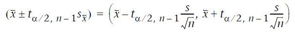

```r
ich<-c(mh - merh, mh + merh)
```

IC valor media en variable happiness: 5.8443838, 5.9457933

Es un intervalo de confianza con un nivel del 90% para la media de los niveles de satisfacción laboral de los trabajadores. Es decir, la media del nivel de satisfacción laboral se encuentra entre 5.8443838, 5.9457933, con una confianza del 90%.

## 3.2 Satisfacción en el trabajo en relación al sexo

Nos preguntamos si existen diferencias significativas en el grado de felicidad (happiness) de los hombres en relación a las mujeres. Para responder a esta pregunta, siga los pasos que se detallan a continuación.

### 3.2.1 Boxplot

Muestra la distribución de happiness de hombres y mujeres por separado en un boxplot. Explica si observas diferencias apreciables visualmente.

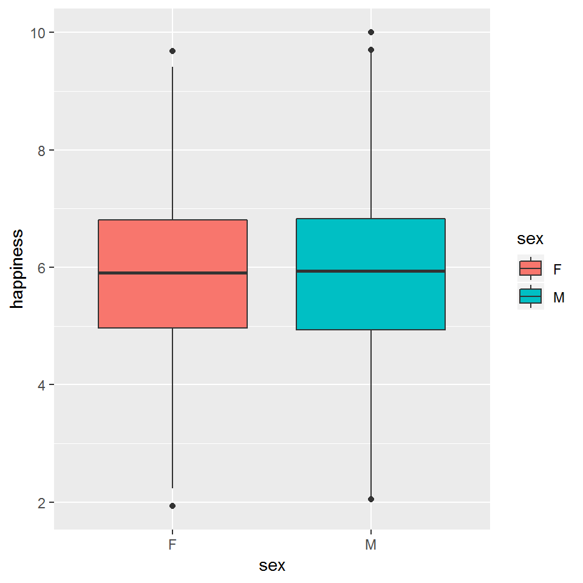

Visualmente parece ser la misma distribución de datos, como si el nivel de satisfacción de los trabajadores no dependiera del sexo

### 3.2.2 Escribir la hipótesis nula y alternativa

**Hipótesis nula, H0**: el nivel de satisfacción medio entre hombres y mujeres no es significativo $(\mu1 - \mu2) = 0$.  
**Hipótesis alternativa, H1**: el nivel de satisfacción medio entre hombres y mujeres es significativo $(\mu1 - \mu2) \neq 0$.

### 3.2.3 Método

Indicar cuál es el método más apropiado para hacer este análisis, en función de las características de la muestra y el objetivo del análisis.

**Contraste sobre la diferencia de medias en el caso de varianzas poblacionales desconocidas pero iguales**.

1. Fijar las hipótesis nula y alternativa.
2. Fijar un nivel de significación.
3. Determinar el estadístico de contraste y su ley.
4. Calcular el p-valor asociado a nuestro estadístico de contraste calculado.
5. Comparar el p-valor con el nivel de significación y tomar una decisión.

### 3.2.4 Calcular el estadístico de contraste, el valor crítico y el valor p.

Nivel de significación: $\alpha = 0,05$

Calculamos los valores para la media y desviación típica muestral para la variable happiness de acuerdo al sexo:

```r
ns<-0.05

#Hombres
n1<-length(data_clean[data_clean$sex=="M", "happiness"])
mm<-mean(data_clean[data_clean$sex == "M", "happiness"])
sdm<-sd(data_clean[data_clean$sex == "M", "happiness"])

#Mujeres
n2<-length(data_clean[data_clean$sex=="F", "happiness"])
mf<-mean(data_clean[data_clean$sex == "F", "happiness"])
sdf<-sd(data_clean[data_clean$sex == "F", "happiness"])
```

**media muestral happiness**: M: 5.8981979, F: 5.8919792  
**desviación típica muestral**: M: 1.3531934 , F: 1.3476756

Calculamos el estadístico de contraste:

```r
dmh<-mm - mf
eshs<- sqrt(((n1-1)*sdm^2 + (n2-1)*sdf^2)/ (n1 + n2 - 2) ) * sqrt( (1/n1) + (1/n2))

tch<- dmh/eshs

tch
```

```
## [1] 0.1008903
```

Calculamos el valor crítico de t para el cual la probabilidad es 0.025, para t con 1918 grados de libertad y $\alpha/2$= 0.025

```r
vct<-abs(qt(ns/2, n1 + n2 - 2))

vct
```

```
## [1] 1.961202
```

Calculamos el p-valor: p = P(t1918 > 0.1008903)

```r
pv<-2*(1-pt(tch,df=n1 + n2 -2))
pv
```

```
## [1] 0.9196481
```

### 3.2.5 Interpretar el resultado

Puesto que el p-value: 0.9196481 > 0.05 , entonces aceptamos la hipótesis nula en rechazo de la hipótesis alternativa, es decir, el nivel de satisfacción medio para la muestra analizada no depende del sexo.

## 3.3 Test no paramétrico

Cuando las asunciones de normalidad no se cumplen, hay que aplicar tests no paramétricos. El test de suma de rangos de Wilcoxon, también llamado Mann-Whitney U-test es el equivalente no paramétrico al test t para dos muestras independientes. En este apartado te pedimos que apliques este test. Se realizará para contrastar si existen diferencias en la antigüedad (seniority) en función del tipo de trabajo (job_type).

### 3.3.1 Hipótesis nula y alternativa

Escribir la hipótesis nula y la alternativa. Recuerda que la pregunta es si existen diferencias significativas en seniority según el tipo de trabajo.

**Hipótesis nula, H0**: el tiempo de antigüedad medio (mediana) en función del tipo de trabajo no es significativo $(\mu1 - \mu2) = 0$.  
**Hipótesis alternativa, H1**: el tiempo de antigüedad medio (mediana) en función del tipo de trabajo es significativo $(\mu1 - \mu2) \neq 0$.

### 3.3.2 Asunción de normalidad

Comprueba si se cumple la asunción de normalidad en los datos. Para hacerlo, puede mostrar los gráficos qqplot() y aplicar el test Shapiro-Wilk.

Quantile-Quantile Plots

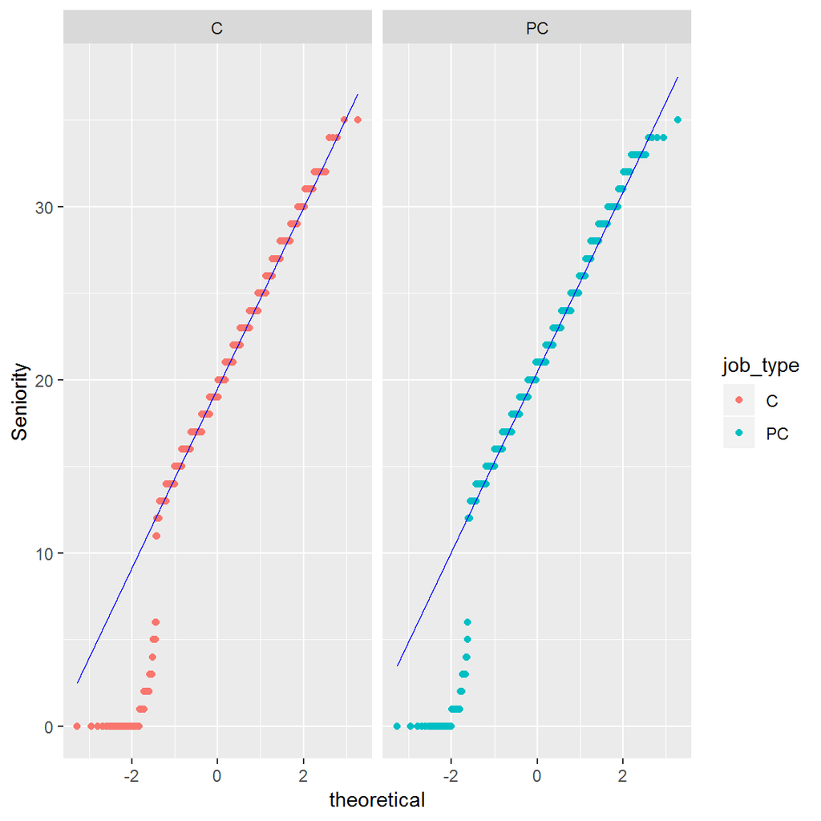

Shapiro-Wilk Test

```r
dsc<-data_clean[data_clean$job_type == "C", "seniority"]
dspc<-data_clean[data_clean$job_type == "PC", "seniority"]

shapiro.test(dsc)$p.value
```

```
## [1] 1.616518e-22
```

```r
shapiro.test(dspc)$p.value
```

```
## [1] 4.159746e-22
```

Se concluye entonces que los datos de la variable seniority no distribuyen normalmente en funcion del tipo de trabajo al ser el p-value menor a $\alpha =$ 0.05

### 3.3.3 Test de la U de Mann-Whitney

Aplica el test de la U de Mann-Whitney para contrastar si existen diferencias significativas en la antigüedad (seniority) en función del tipo de trabajo (job_type). Puedes usar la función wilcox.test().

```r
wilcox.test(seniority ~ job_type, data = data_clean)
```

```
##
##  Wilcoxon rank sum test with continuity correction
##
## data:  seniority by job_type
## W = 413020, p-value = 8.141e-05
## alternative hypothesis: true location shift is not equal to 0
```

```r
wilcox.test(dsc, dspc)
```

```
##
##  Wilcoxon rank sum test with continuity correction
##
## data:  dsc and dspc
## W = 413020, p-value = 8.141e-05
## alternative hypothesis: true location shift is not equal to 0
```

### 3.3.4 Cálculos manuales

Con el fin de profundizar en las operaciones del test de suma de rangos de Wilcoxon, realiza los cálculos de la suma de rangos y resuelve el contraste.

http://www.real-statistics.com/non-parametric-tests/mann-whitney-test/

```r
library(plyr)

#Seleccion de variables
seniority.ord<-data_clean[order(data_clean$seniority), c("seniority","job_type")]

#creacion de rangos
seniority.ord$ranked<-rank(seniority.ord$seniority)

#Seleccion de variable seniority rango dado job_type
sc<- seniority.ord[seniority.ord$job_type == "C", c("seniority","ranked")]

spc<-seniority.ord[seniority.ord$job_type == "PC", c("seniority","ranked")]

#Formula para calcular valores de R
R1 <- sum(sc$ranked)
R2 <- sum(spc$ranked)

#Tamaños de muestra, para n1 y n2 grandes (> 25) el estadistico U es aproximadamente normal N(μ, σ)

n1 <- length(sc$ranked)
n2 <- length(spc$ranked)

#Formula para calcular valores de U
U1 <- n1 * n2 + (n1 * (n1 + 1) / 2) - R1
U2 <- n1 * n2 + (n2 * (n2 + 1) / 2) - R2

U <- min(U1, U2)
U
```

```
## [1] 413024.5
```

```r
rank.counts <- count(seniority.ord, vars = "ranked")

# total de la muestra
n <- n1 + n2


# Estimacion de la media
mu = (n1 * n2) / 2

# Desviaciones estandar corregidas
sigma_1 = ((n1 * n2) * (n + 1)) / 12
sigma_2 = 1 - sum((rank.counts$freq^3 - rank.counts$freq) / (n^3 - n))

# Desviacion estandar final corregida
sigma = sqrt(sigma_1 * sigma_2)

# z-score
z <- (abs(U - mu)) / sigma
z
```

```
## [1] 3.940238
```

```r
# U critico
Uc<-mu+sigma*qnorm(ns/2)-0.05
Uc
```

```
## [1] 437035.3
```

```r
#Valor p
p<-(1-pnorm(z)) * 2 # valor de p para 2 colas
p
```

```
## [1] 8.140075e-05
```

### 3.3.5 Interpretación

Interpreta el resultado del test.

En vista que p-value es menor que $\alpha =$ 0.05, entonces rechazamos la hipótesis nula en favor de la hipótesis alternativa, es decir el tipo de trabajo si tiene algun nivel de incidencia en el tiempo medio (mediana) de antigüedad de los trabajadores.

### 3.3.6 Reflexión sobre tests paramétricos y no paramétricos

Si los tests no paramétricos no presentan asunciones sobre la normalidad de los datos, y por tanto, son menos restrictivos en su aplicabilidad, ¿por qué no se usan los tests no paramétricos como primera opción (u opción por defecto)?

**Limitaciones de las pruebas no paramétricas**

Las pruebas no paramétricas por lo general son menos potentes que la prueba paramétrica correspondiente cuando se cumple el supuesto de normalidad. Por lo tanto, es menos probable que se rechace la hipótesis nula cuando sea falsa si los datos provienen de la distribución normal.

Las pruebas no paramétricas suelen requerir que se modifiquen las hipótesis. Por ejemplo, la mayoría de las pruebas no paramétricas acerca del centro de la población son pruebas sobre la mediana y no sobre la media. La prueba no responde a la misma pregunta que el procedimiento paramétrico correspondiente si la población no es simétrica respecto a la mediana.

La ventaja de usar una prueba paramétrica en lugar de una no paramétrica consiste en que la primera tiene más potencia estadística que la segunda. En otras palabras, una prueba paramétrica tiene mayor capacidad para conducir a un rechazo de H0. La mayoría de las veces, el valor p asociado a una prueba paramétrica es menor que el valor p asociado a su equivalente no paramétrica ejecutada sobre los mismos datos.

## 3.4 Test sobre el nivel de colesterol

A continuación nos preguntamos si el nivel de colesterol de los trabajadores ha aumentado en la última revisión en relación a la penúltima revisión. Aplica un test adecuado para realizar este contraste.

[figure not shown]

### 3.4.1 Hipótesis nula y alternativa

Escribir la hipótesis nula y la alternativa.

La variable sobre la cual se realizara el análisis es la resultante de la diferencia de *Cho_initial - Cho_final*, por lo tanto una tendencia central relacionada al incremento debera corresponder a una mayor cantidad de valores negativos en dicha variable.

**Hipótesis nula, H0**: no ha habido un aumento en el nivel de colesterol medio de los trabajadores en la última revisión respecto a la penúltima revisión. $\mu = 0$.  
**Hipótesis alternativa, H1**: si ha habido un aumento en el nivel de colesterol medio de los trabajadores en la última revisión respecto a la penúltima revisión. $\mu < 0$.

### 3.4.2 Método

Escribir el método que utilizarás para realizar el contraste y las asunciones sobre los datos que se adoptan. Si es necesario, aplica tests para validar las asunciones sobre los datos.

**Constrate sobre la media para la variable colesterol, varianza desconocida y datos aparejados.**

Una muestra de datos aparejados es un conjunto de observaciones de dos variables diferentes observadas en los mismos individuos, de manera que por cada individuo tenemos dos observaciones.

El método parte del hecho que la variable presenta una distribución normal, mostremos los gráficos qqplot() y el test Shapiro-Wilk para confirmar dicha asunción.

Quantile-Quantile Plots

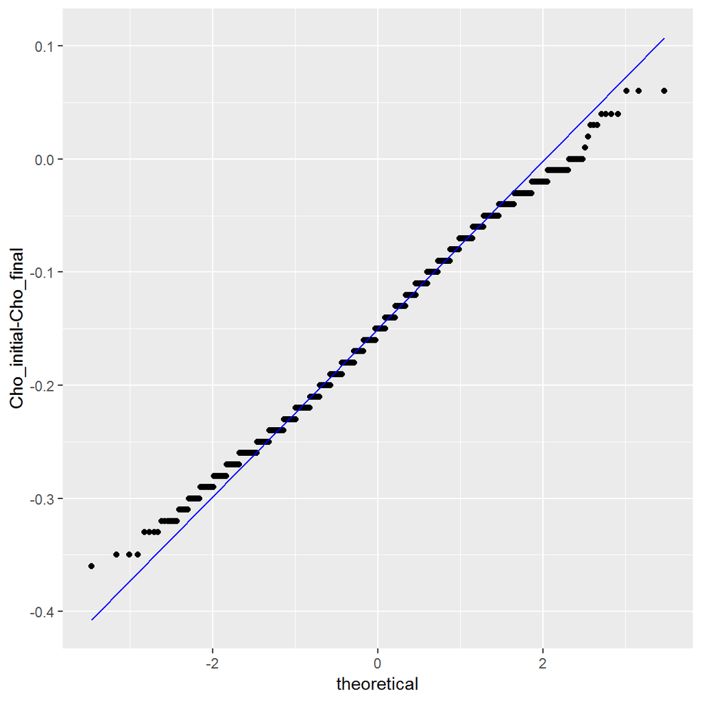

Shapiro-Wilk Test

```r
dtc<-dci-dcf

shapiro.test(dtc)$p.value
```

```
## [1] 8.166014e-07
```

Como el valor de p es menor a $\alpha =$ 0.05 , rechazamos la hipotesis nula en favor de la hispótesis alternativa, es decir, los datos no siguen una distribución normal. Bajo este escenario, se utilizara un test no parametrico para datos aparejados (Wilcoxon Signed-Ranks Test for Paired Samples)

http://www.real-statistics.com/non-parametric-tests/wilcoxon-signed-ranks-test/

### 3.4.3 Cálculos

Realizar todos los cálculos que procedan: estadístico de contraste, valor crítico, p valor, . . .

```r
#Filtrar valores diferentes de cero
diff <- dtc[ which(dtc!=0) ]
nct<-length(diff)

diff.rank <- rank(abs(diff)) #rangos en valor absoluto
diff.rank.sign <- diff.rank * sign(diff) #validar signo de los rangos

ranks.pos <- sum(diff.rank.sign[diff.rank.sign > 0])
ranks.neg <- -sum(diff.rank.sign[diff.rank.sign < 0])

ranks.pos
```

```
## [1] 1114.5
```

```r
ranks.neg
```

```
## [1] 1827714
```

```r
#valor T
Tv<- min(ranks.pos,ranks.neg)
Tv
```

```
## [1] 1114.5
```

```r
# Para valores de n>25, T distribuye normal con media y sd:

#media
mcho<-(nct*(nct+1))/4
mcho
```

```
## [1] 914414
```

```r
#Frecuencia de rangos
rank.f <- count(diff.rank)

#desviacion estandar
sdcho1<- (nct*(nct+1)*(2*(nct+1)))/24
sdcho2<- 1/48 * sum((rank.f$freq^3 - rank.f$freq))

sdcho<-sqrt(sdcho1-sdcho2)
sdcho
```

```
## [1] 24144.67
```

```r
#z-score
zcho<-(Tv-mcho)/sdcho
zcho
```

```
## [1] -37.82613
```

```r
#valor T critico
Tvc<-mcho+sdcho*qnorm(ns)-0.05
Tvc
```

```
## [1] 874699.5
```

```r
#valor p
pv<-pnorm(zcho)
pv
```

```
## [1] 0
```

```r
wilcox.test(dci, dcf, paired=TRUE, alternative="less")
```

```
##
##  Wilcoxon signed rank test with continuity correction
##
## data:  dci and dcf
## V = 1114.5, p-value < 2.2e-16
## alternative hypothesis: true location shift is less than 0
```

### 3.4.4 Interpretación

Como el valor de p es menor a $\alpha =$ 0.05 y el valor de T < Tcritico , rechazamos la hipotesis nula en favor de la hispótesis alternativa, es decir, si ha habido un aumento en el nivel de colesterol medio (mediana) de los trabajadores en la última revisión respecto a la penúltima revisión.

# 4 Reflexión final

Los intervalos de confianza nos permiten aproximar, una vez calculado el valor de la variable objeto de estudio en la muestra, entre qué rango de valores se encuentra el valor real inaccesible de la variable en la población, con un grado de incertidumbre que podemos determinar. Además, los intervalos de confianza aportan información añadida que se pierde cuando únicamente se valora la probabilidad de significación estadística, ya que nos permiten estudiar la precisión de la estimación del estudio y la relevancia de los resultados.

Podríamos decir que la estadística inferencial se divide en dos ramas: paramétrica y no paramétrica. La diferencia entre estas dos radica en el cumplimiento de tres supuestos básicos en el caso de la estadística paramétrica: comportamiento gaussiano de los datos (distribución normal o campana de Gauss), tamaño de la muestra n>30 (extraídas aleatoriamente y que sean independientes) y homocedasticidad, es decir, que las varianzas entre las distribuciones sean homogéneas. Por otra parte las pruebas no paramétricas son más flexible en la aplicación de los supuestos, algunos autores señalan que estas pruebas facilitan soluciones más sencillas y existe una gran diversidad de pruebas no paramétricas como alternativa a las paramétricas.

Las pruebas no paramétricas son aquellas que se encargan de analizar datos que no tienen una distribución particular y se basan en una hipótesis, pero los datos no están organizados de forma normal. Aunque tienen algunas limitaciones, cuentan con resultados estadísticos ordenados que facilita su comprensión.

Las pruebas paramétricas, en cambio, se basan en las leyes de distribución normal para analizar los elementos de una muestra. Generalmente, solo se aplican a variables numéricas y para su análisis debe mantener una población grande, ya que permite que el cálculo sea más exacto.